# Assignement 2, Data science in practice, MGT-415, 22.03.2020

### Aubry Yannick, Fontannaz Benoît, Muret Gabriel Pierre Etienne, Tedeschi Julien Brian, Terrier Cédric

```python
import numpy as np
import pandas as pd
import matplotlib.pyplot as plt
import seaborn as sns
from sklearn.metrics import precision_score, recall_score, confusion_matrix
import scikitplot as skplt

from sklearn.preprocessing import MinMaxScaler
from sklearn.decomposition import PCA
from sklearn import metrics
from sklearn.neighbors import KNeighborsClassifier
from sklearn.ensemble import RandomForestRegressor
```

# Data treatment

## In this section, the data are prepared for the learning process.

```python
data = pd.read_csv('customers.csv')
print(data.shape)
print(data.dtypes)
data.head()
```

```
(7043, 21)
customerID           object
gender               object
SeniorCitizen         int64
Partner              object
Dependents           object
tenure                int64
PhoneService         object
MultipleLines        object
InternetService      object
OnlineSecurity       object
OnlineBackup         object
DeviceProtection     object
TechSupport          object
StreamingTV          object
StreamingMovies      object
Contract             object
PaperlessBilling     object
PaymentMethod        object
MonthlyCharges      float64
TotalCharges         object
Churn                object
dtype: object
```

|  | customerID | gender | SeniorCitizen | Partner | Dependents | tenure | PhoneService | MultipleLines | InternetService | OnlineSecurity | ... | DeviceProtection | TechSupport | StreamingTV | StreamingMovies | Contract | PaperlessBilling | PaymentMethod | MonthlyCharges | TotalCharges | Churn |
| --- | --- | --- | --- | --- | --- | --- | --- | --- | --- | --- | --- | --- | --- | --- | --- | --- | --- | --- | --- | --- | --- |
| 0 | 7590-VHVEG | Female | 0 | Yes | No | 1 | No | No phone service | DSL | No | ... | No | No | No | No | Month-to-month | Yes | Electronic check | 29.85 | 29.85 | No |
| 1 | 5575-GNVDE | Male | 0 | No | No | 34 | Yes | No | DSL | Yes | ... | Yes | No | No | No | One year | No | Mailed check | 56.95 | 1889.5 | No |
| 2 | 3668-QPYBK | Male | 0 | No | No | 2 | Yes | No | DSL | Yes | ... | No | No | No | No | Month-to-month | Yes | Mailed check | 53.85 | 108.15 | Yes |
| 3 | 7795-CFOCW | Male | 0 | No | No | 45 | No | No phone service | DSL | Yes | ... | Yes | Yes | No | No | One year | No | Bank transfer (automatic) | 42.30 | 1840.75 | No |
| 4 | 9237-HQITU | Female | 0 | No | No | 2 | Yes | No | Fiber optic | No | ... | No | No | No | No | Month-to-month | Yes | Electronic check | 70.70 | 151.65 | Yes |

5 rows × 21 columns

### The data a translated into numbers to allow the classifier to understand them

```python
DataFrame=data.copy()

DataFrame.gender=DataFrame.gender.replace("Male",1)
DataFrame.gender=DataFrame.gender.replace("Female",0)

DataFrame.Partner=DataFrame.Partner.replace("Yes",1)
DataFrame.Partner=DataFrame.Partner.replace("No",0)

DataFrame.Dependents=DataFrame.Dependents.replace("Yes",1)
DataFrame.Dependents=DataFrame.Dependents.replace("No",0)

DataFrame.PhoneService=DataFrame.PhoneService.replace("Yes",1)
DataFrame.PhoneService=DataFrame.PhoneService.replace("No",0)

DataFrame.MultipleLines=DataFrame.MultipleLines.replace("Yes",2)
DataFrame.MultipleLines=DataFrame.MultipleLines.replace("No",1)
DataFrame.MultipleLines=DataFrame.MultipleLines.replace("No phone service",0)

DataFrame.InternetService=DataFrame.InternetService.replace("Fiber optic",2)
DataFrame.InternetService=DataFrame.InternetService.replace("DSL",1)
DataFrame.InternetService=DataFrame.InternetService.replace("No",0)

DataFrame.OnlineSecurity=DataFrame.OnlineSecurity.replace("Yes",2)
DataFrame.OnlineSecurity=DataFrame.OnlineSecurity.replace("No",1)
DataFrame.OnlineSecurity=DataFrame.OnlineSecurity.replace("No internet service",0)

DataFrame.OnlineBackup=DataFrame.OnlineBackup.replace("Yes",2)
DataFrame.OnlineBackup=DataFrame.OnlineBackup.replace("No",1)
DataFrame.OnlineBackup=DataFrame.OnlineBackup.replace("No internet service",0)

DataFrame.DeviceProtection=DataFrame.DeviceProtection.replace("Yes",2)
DataFrame.DeviceProtection=DataFrame.DeviceProtection.replace("No",1)
DataFrame.DeviceProtection=DataFrame.DeviceProtection.replace("No internet service",0)

DataFrame.TechSupport=DataFrame.TechSupport.replace("Yes",2)
DataFrame.TechSupport=DataFrame.TechSupport.replace("No",1)
DataFrame.TechSupport=DataFrame.TechSupport.replace("No internet service",0)

DataFrame.StreamingTV=DataFrame.StreamingTV.replace("Yes",2)
DataFrame.StreamingTV=DataFrame.StreamingTV.replace("No",1)
DataFrame.StreamingTV=DataFrame.StreamingTV.replace("No internet service",0)

DataFrame.StreamingMovies=DataFrame.StreamingMovies.replace("Yes",2)
DataFrame.StreamingMovies=DataFrame.StreamingMovies.replace("No",1)
DataFrame.StreamingMovies=DataFrame.StreamingMovies.replace("No internet service",0)

DataFrame.Contract=DataFrame.Contract.replace("Two year",24)
DataFrame.Contract=DataFrame.Contract.replace("One year",12)
DataFrame.Contract=DataFrame.Contract.replace("Month-to-month",1)

DataFrame.PaperlessBilling=DataFrame.PaperlessBilling.replace("Yes",1)
DataFrame.PaperlessBilling=DataFrame.PaperlessBilling.replace("No",0)

DataFrame.PaymentMethod=DataFrame.PaymentMethod.replace("Electronic check",3)
DataFrame.PaymentMethod=DataFrame.PaymentMethod.replace("Mailed check",2)
DataFrame.PaymentMethod=DataFrame.PaymentMethod.replace("Bank transfer (automatic)",1)
DataFrame.PaymentMethod=DataFrame.PaymentMethod.replace("Credit card (automatic)",0)

DataFrame.TotalCharges=DataFrame.Contract*DataFrame.MonthlyCharges

DataFrame.Churn=DataFrame.Churn.replace("Yes",1)
DataFrame.Churn=DataFrame.Churn.replace("No",0)


DataFrame.head()
```

|  | customerID | gender | SeniorCitizen | Partner | Dependents | tenure | PhoneService | MultipleLines | InternetService | OnlineSecurity | ... | DeviceProtection | TechSupport | StreamingTV | StreamingMovies | Contract | PaperlessBilling | PaymentMethod | MonthlyCharges | TotalCharges | Churn |
| --- | --- | --- | --- | --- | --- | --- | --- | --- | --- | --- | --- | --- | --- | --- | --- | --- | --- | --- | --- | --- | --- |
| 0 | 7590-VHVEG | 0 | 0 | 1 | 0 | 1 | 0 | 0 | 1 | 1 | ... | 1 | 1 | 1 | 1 | 1 | 1 | 3 | 29.85 | 29.85 | 0 |
| 1 | 5575-GNVDE | 1 | 0 | 0 | 0 | 34 | 1 | 1 | 1 | 2 | ... | 2 | 1 | 1 | 1 | 12 | 0 | 2 | 56.95 | 683.40 | 0 |
| 2 | 3668-QPYBK | 1 | 0 | 0 | 0 | 2 | 1 | 1 | 1 | 2 | ... | 1 | 1 | 1 | 1 | 1 | 1 | 2 | 53.85 | 53.85 | 1 |
| 3 | 7795-CFOCW | 1 | 0 | 0 | 0 | 45 | 0 | 0 | 1 | 2 | ... | 2 | 2 | 1 | 1 | 12 | 0 | 1 | 42.30 | 507.60 | 0 |
| 4 | 9237-HQITU | 0 | 0 | 0 | 0 | 2 | 1 | 1 | 2 | 1 | ... | 1 | 1 | 1 | 1 | 1 | 1 | 3 | 70.70 | 70.70 | 1 |

5 rows × 21 columns

### We check if the type of every variable is either an int or a float. The customer ID is not a relevant variable as it does not affect the churn a-priori. So it will be removed later

```python
print(DataFrame.dtypes)
```

```
customerID           object
gender                int64
SeniorCitizen         int64
Partner               int64
Dependents            int64
tenure                int64
PhoneService          int64
MultipleLines         int64
InternetService       int64
OnlineSecurity        int64
OnlineBackup          int64
DeviceProtection      int64
TechSupport           int64
StreamingTV           int64
StreamingMovies       int64
Contract              int64
PaperlessBilling      int64
PaymentMethod         int64
MonthlyCharges      float64
TotalCharges        float64
Churn                 int64
dtype: object
```

```python
for col in DataFrame.columns:
    print(DataFrame[col].value_counts(normalize=True))
```

```
6458-CYIDZ    0.000142
6582-OIVSP    0.000142
3541-ZNUHK    0.000142
0684-AOSIH    0.000142
9133-AYJZG    0.000142
                ...
4806-DXQCE    0.000142
6773-LQTVT    0.000142
2408-PSJVE    0.000142
8329-IBCTI    0.000142
2162-FRZAA    0.000142
Name: customerID, Length: 7043, dtype: float64
1    0.504756
0    0.495244
Name: gender, dtype: float64
0    0.837853
1    0.162147
Name: SeniorCitizen, dtype: float64
0    0.516967
1    0.483033
Name: Partner, dtype: float64
0    0.700412
1    0.299588
Name: Dependents, dtype: float64
1     0.087037
72    0.051399
2     0.033792
3     0.028397
4     0.024989
        ...
28    0.008093
39    0.007951
44    0.007241
36    0.007099
0     0.001562
Name: tenure, Length: 73, dtype: float64
1    0.903166
0    0.096834
Name: PhoneService, dtype: float64
1    0.481329
```

[output cut: 55 more lines]

```
20.05      0.003976
476.40     0.002982
472.80     0.002982
20.00      0.002840
469.20     0.002840
             ...
25.90      0.000142
2463.60    0.000142
103.80     0.000142
1167.00    0.000142
53.10      0.000142
Name: TotalCharges, Length: 2809, dtype: float64
0    0.73463
1    0.26537
Name: Churn, dtype: float64
```

```python
print(DataFrame['Churn'].value_counts(normalize=True))
```

```
0    0.73463
1    0.26537
Name: Churn, dtype: float64
```

### We prepare the X variables

```python
df = DataFrame.drop(columns=["customerID" ,"Churn"])
df.head()
```

|  | gender | SeniorCitizen | Partner | Dependents | tenure | PhoneService | MultipleLines | InternetService | OnlineSecurity | OnlineBackup | DeviceProtection | TechSupport | StreamingTV | StreamingMovies | Contract | PaperlessBilling | PaymentMethod | MonthlyCharges | TotalCharges |
| --- | --- | --- | --- | --- | --- | --- | --- | --- | --- | --- | --- | --- | --- | --- | --- | --- | --- | --- | --- |
| 0 | 0 | 0 | 1 | 0 | 1 | 0 | 0 | 1 | 1 | 2 | 1 | 1 | 1 | 1 | 1 | 1 | 3 | 29.85 | 29.85 |
| 1 | 1 | 0 | 0 | 0 | 34 | 1 | 1 | 1 | 2 | 1 | 2 | 1 | 1 | 1 | 12 | 0 | 2 | 56.95 | 683.40 |
| 2 | 1 | 0 | 0 | 0 | 2 | 1 | 1 | 1 | 2 | 2 | 1 | 1 | 1 | 1 | 1 | 1 | 2 | 53.85 | 53.85 |
| 3 | 1 | 0 | 0 | 0 | 45 | 0 | 0 | 1 | 2 | 1 | 2 | 2 | 1 | 1 | 12 | 0 | 1 | 42.30 | 507.60 |
| 4 | 0 | 0 | 0 | 0 | 2 | 1 | 1 | 2 | 1 | 1 | 1 | 1 | 1 | 1 | 1 | 1 | 3 | 70.70 | 70.70 |

### And the Y variable (churn)

```python
y = DataFrame["Churn"]
y.head()
```

```
0    0
1    0
2    1
3    0
4    1
Name: Churn, dtype: int64
```

```python
x = df.to_numpy()
y = y.to_numpy()
print(x, y)
```

```
[[0.0000e+00 0.0000e+00 1.0000e+00 ... 3.0000e+00 2.9850e+01 2.9850e+01]
 [1.0000e+00 0.0000e+00 0.0000e+00 ... 2.0000e+00 5.6950e+01 6.8340e+02]
 [1.0000e+00 0.0000e+00 0.0000e+00 ... 2.0000e+00 5.3850e+01 5.3850e+01]
 ...
 [0.0000e+00 0.0000e+00 1.0000e+00 ... 3.0000e+00 2.9600e+01 2.9600e+01]
 [1.0000e+00 1.0000e+00 1.0000e+00 ... 2.0000e+00 7.4400e+01 7.4400e+01]
 [1.0000e+00 0.0000e+00 0.0000e+00 ... 1.0000e+00 1.0565e+02 2.5356e+03]] [0 0 1 ... 0 1 0]
```

### We sort the churn and no churn values

```python
no_churn = np.where(y==0)
churn = np.where(y==1)
x_no_churn = x[no_churn, :][0]
y_no_churn = y[no_churn]
x_churn = x[churn, :][0]
y_churn = y[churn]
```

```python
print(x_no_churn.shape)
print(y_no_churn.shape)
print(x_churn.shape)
print(y_churn.shape)
```

```
(5174, 19)
(5174,)
(1869, 19)
(1869,)
```

### Swap line order

```python
randomize1 = np.arange(x_no_churn.shape[0])
np.random.shuffle(randomize1)
x_no_churn = x_no_churn[randomize1]
y_no_churn = y_no_churn[randomize1]

randomize2 = np.arange(x_churn.shape[0])
np.random.shuffle(randomize2)
x_churn = x_churn[randomize2]
y_churn = y_churn[randomize2]

print(x_no_churn.shape)
print(y_no_churn.shape)
print(x_churn.shape)
print(y_churn.shape)

x_no_churn = x_no_churn[:x_churn.shape[0], :]
y_no_churn = y_no_churn[:x_churn.shape[0]]
print("Rebalancing (50% Churn 50% no churn)")

print(x_no_churn.shape)
print(y_no_churn.shape)
print(x_churn.shape)
print(y_churn.shape)
```

```
(5174, 19)
(5174,)
(1869, 19)
(1869,)
Rebalancing (50% Churn 50% no churn)
(1869, 19)
(1869,)
(1869, 19)
(1869,)
```

### We can build the train and test set of values. A ratio 80% - 20% is taken

```python
train_ratio = 0.8
split_churn = int(x_churn.shape[0]*train_ratio)
split_no_churn = int(x_no_churn.shape[0]*train_ratio)
print(split_churn)
print(split_no_churn)

# Train set
x_train = np.concatenate((x_no_churn[:split_no_churn, :], x_churn[:split_churn, :]), axis=0)
y_train = np.concatenate((y_no_churn[:split_no_churn], y_churn[:split_churn]))

randomize3 = np.arange(x_train.shape[0])
np.random.shuffle(randomize3)
x_train = x_train[randomize3]
y_train = y_train[randomize3]

# Test set
x_test = np.concatenate((x_no_churn[split_no_churn:, :], x_churn[split_churn:, :]), axis=0)
y_test = np.concatenate((y_no_churn[split_no_churn:], y_churn[split_churn:]))

randomize4 = np.arange(x_test.shape[0])
np.random.shuffle(randomize4)
x_test = x_test[randomize4]
y_test = y_test[randomize4]

print(x_test.shape)
print(x_train.shape)
```

```
1495
1495
(748, 19)
(2990, 19)
```

### Finally, we scale the data to the same scale and we perform a PCA. It requires 10 variables to define 90% of the variance

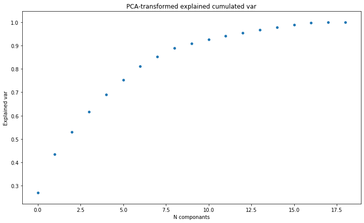

```
(748, 19)
PCA
(748, 10)
```

```python
scaler = MinMaxScaler()
scaler.fit(x_train)
scaled_x_train = scaler.transform(x_train)
scaled_x_test = scaler.transform(x_test)

pca = PCA()
pca.fit(scaled_x_train)
var_explained=np.cumsum(pca.explained_variance_ratio_)

plt.figure(figsize=(12, 7))
ax = sns.scatterplot(data=var_explained)
ax.set(xlabel='N componants', ylabel='Explained var')
plt.title("PCA-transformed explained cumulated var")
plt.show()

pca = PCA(n_components=10)
pca.fit(scaled_x_train)
var_explained=np.cumsum(pca.explained_variance_ratio_)

input_x_train = pca.transform(scaled_x_train)
input_x_test = pca.transform(scaled_x_test)

print(scaled_x_test.shape)
print("PCA")
print(input_x_test.shape)
```

# Classification

## In this section, several classification method are used (logistic regression and closest neighbors). The results are analysed with the confusion matrix and the ROC curves

```python
from sklearn.linear_model import LogisticRegression
clf = LogisticRegression(random_state=3, solver = 'liblinear').fit(input_x_train, y_train)
y_pred = clf.predict(input_x_test)
```

### We build some functions to analyse the results and plot the confusion matrix

```python
def result_analysis(y: np.ndarray, y_pred: np.ndarray): #Fonction Analyse de Précision, renvoi recall, précision et F-Score
    Recall = recall_score(y,y_pred) #true positif/(true positif+false negatif)
    Precision = precision_score(y,y_pred) #=true positif/(true positif+false positive)
    Fscore = 2*(Precision*Recall)/(Precision+Recall) #Classique Classifier score
    return(Recall, Precision, Fscore)

def Confusion(y: np.ndarray, y_pred: np.ndarray): #Renvoie la matrice de Confusion pour notre prédiction (à utiliser que pour avoir l'image de la matrice de confusion, donc sur le meilleur classifier)
    Conf = confusion_matrix(y, y_pred)
    Confshow = skplt.metrics.plot_confusion_matrix(y, y_pred, normalize=True)
```

### The results of the logistic regression is more accurate to predict if a person will churn than if a person will stay in the company. Indeed, the classifier predicted correctly only 70% of the people that were staying in the company wheras it predicts correctly the 83% of the people that were leaving. Therefore, it tends to be more pessimist than it is in reality.

```
Precision : 73.58490566037736 %
Fscore : 0.7819548872180452
```

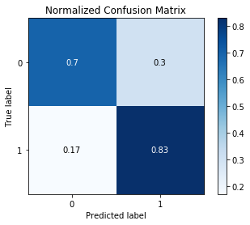

```python
(Recall, Precision, Fscore) = result_analysis(y_test, y_pred)

print("Precision :", Precision*100,"% ")
print("Fscore :", Fscore)
#print("Mean of" ,np.mean(y_test)*100,"% have truly churned whereas", np.mean(y_pred)*100, "% is predicted")

Confusion(y_test, y_pred)
```

```
Precision : 74.73958333333334 %
Fscore : 0.7572559366754618
```

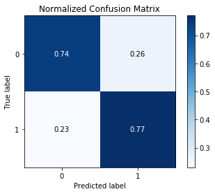

```python
classifier = KNeighborsClassifier(n_neighbors=10)
classifier.fit(input_x_train, y_train)
y_guessed = classifier.predict(input_x_test)

(Recall, Precision, Fscore) = result_analysis(y_test, y_guessed)  #Result Analysis KNN

print("Precision :", Precision*100,"% ")
print("Fscore :", Fscore)

Confusion(y_test, y_guessed)
```

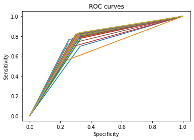

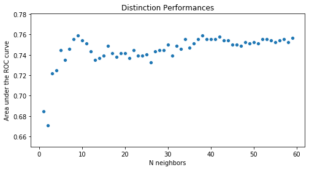

```python
neighbors_range = 60
roc_auc = np.zeros(neighbors_range-1)
for i in range(1, neighbors_range):
    classifier = KNeighborsClassifier(n_neighbors=i)
    classifier.fit(input_x_train, y_train)
    y_guessed = classifier.predict(input_x_test)

    fpr, tpr, thresholds = metrics.roc_curve(y_test, y_guessed)
    roc_auc[i-1] = metrics.auc(fpr, tpr)
    plt.plot(fpr, tpr)

plt.xlabel('Specificity')
plt.ylabel('Sensitivity')
plt.title("ROC curves")
#plt.legend(['Neighbors = %d' %i for i in range(1, neighbors_range)])
plt.show()


plt.figure(figsize=(8, 4))
x = range(1, neighbors_range)
ax = sns.scatterplot(x, roc_auc)
ax.set(xlabel='N neighbors', ylabel='Area under the ROC curve')
plt.title("Distinction Performances")
```

```
Optimal number of neighbors:  9
Precision : 73.20574162679426 %
Fscore : 0.7727272727272727
```

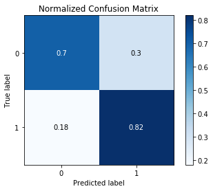

```python
best_n = x[np.argmax(roc_auc)]
print("Optimal number of neighbors: ", best_n)

classifier = KNeighborsClassifier(n_neighbors=best_n)
classifier.fit(input_x_train, y_train)
y_guessed = classifier.predict(input_x_test)
(Recall, Precision, Fscore) = result_analysis(y_test, y_guessed)  #Result Analysis KNN

print("Precision :", Precision*100,"% ")
print("Fscore :", Fscore)

Confusion(y_test, y_guessed)
```

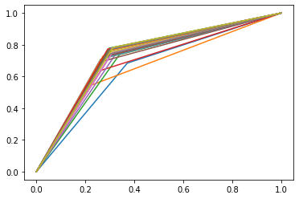

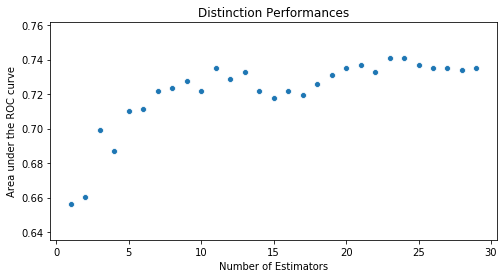

```python
#RANDOM FOREST
est_max=30
roc_auc = np.zeros(est_max-1)
for i in range(1,est_max):
    regressor = RandomForestRegressor(n_estimators=i, random_state=0)
    regressor.fit(input_x_train, y_train)
    y_rd = regressor.predict(input_x_test)
    y_rd = np.around(y_rd, decimals=0)

    fpr, tpr, thresholds = metrics.roc_curve(y_test, y_rd)
    roc_auc[i-1] = metrics.auc(fpr, tpr)
    plt.plot(fpr, tpr)

plt.figure(figsize=(8, 4))
x = range(1, est_max)
ax = sns.scatterplot(x, roc_auc)
ax.set(xlabel='Number of Estimators', ylabel='Area under the ROC curve')
plt.title("Distinction Performances")
```

```
Optimal number of estimators:  23
Recall : 77.80748663101605 %
Precision : 72.38805970149254 %
Fscore : 0.75
```

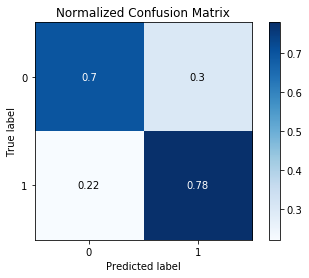

```python
best_n = x[np.argmax(roc_auc)]
print("Optimal number of estimators: ", best_n)

regressor = RandomForestRegressor(n_estimators=best_n, random_state=0)
regressor.fit(input_x_train, y_train)
y_rd = regressor.predict(input_x_test)
y_rd = np.around(y_rd, decimals=0)

(Recall, Precision, Fscore) = result_analysis(y_test, y_rd)  #Result Analysis Random Forest

print("Recall :", Recall*100,"%")
print("Precision :", Precision*100,"% ")
print("Fscore :", Fscore)
Confusion(y_test, y_rd)
```